# Alpha Diversity Analysis

Nidhi Vijayan

2025-11-01

```r
## alpha diversity ====
library(lme4)
library(lmerTest)
library(knitr)
library(dplyr)
library(phyloseq)
library(vegan)
library(emmeans)
library(tibble)
library(reshape2)
library(tidyverse)
library(qiime2R)
library(ggpubr)
library(ggplot2)

theme_set(theme_bw())

load("qiime_f.RData")
metadata_df<-as.data.frame(sample_data(qiime_f))
metadata_df$SampleID<-rownames(metadata_df)
metadata_df<-as.matrix(metadata_df)

qiime_f_rare<-rarefy_even_depth(qiime_f,sample.size = min(sample_sums(qiime_f)))

alpha.div.df <- estimate_richness(
  qiime_f_rare,
  measures=c("Shannon", "Observed")) %>%
  rownames_to_column("SampleID") %>%
  merge(metadata_df, by="SampleID")

alpha.div.long.df <- alpha.div.df %>%
  pivot_longer(c(Shannon, Observed), names_to="metric")

alpha.div.long.df$month_n<-as.numeric(alpha.div.long.df$month_n)

# summarize across sexes
alpha.div.plot.df <- alpha.div.long.df %>%
  dplyr::filter(metric %in% c("Shannon", "Observed")) %>%
  dplyr::filter(month_n <= 40) %>% # omit the few 46 month samples

  # compute mean and SD across diets (separately for each metric)
  group_by(metric, sex, month_n) %>%
  summarise(n=n(),
            mean = mean(value),
            sd = sd(value),
            sem = sd(value)/sqrt(n()), .groups="drop") %>%

  # make sure we have at least 3 observations at this age combination
  dplyr::filter(n >= 2) #%>%

#plot Fig 2 alpha ====
alpha.div.plot.df <- alpha.div.plot.df %>%
  arrange(metric, sex, month_n)
```

## 1 Alpha diversity plot

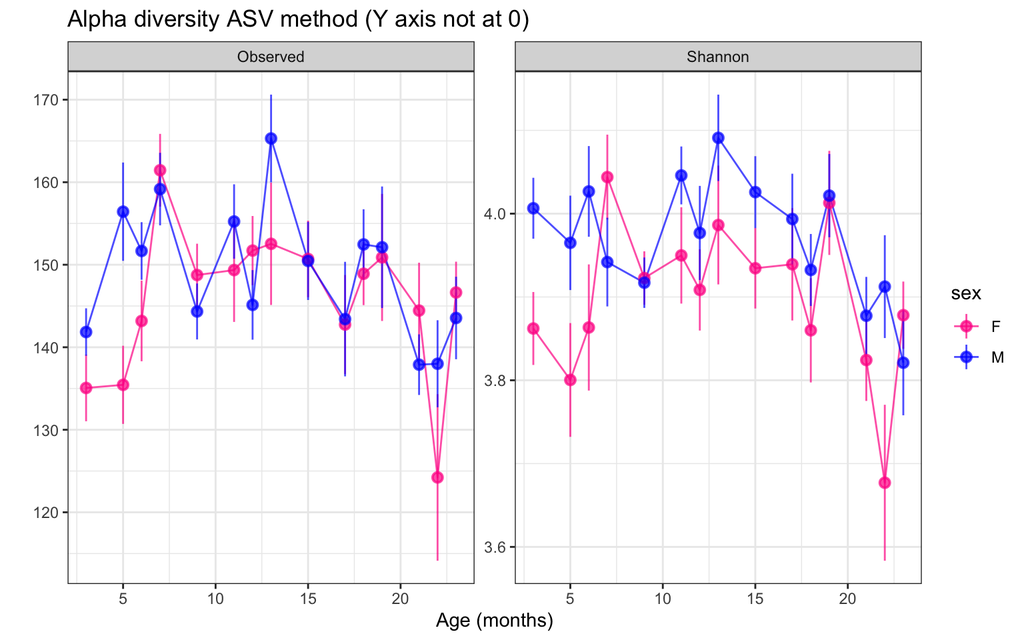

```r
alpha.div.plot.df %>%
  ggplot(aes(
    x = month_n, y = mean,
    ymin = mean - sem, ymax = mean + sem,
    color = sex
  )) +
  geom_path(alpha = 0.7) +
  geom_pointrange(alpha = 0.7) +
  facet_wrap(~ metric, scales = "free", nrow = 1) +
  scale_color_manual(values = c("deeppink", "blue")) +
  labs(
    x = "Age (months)",
    y = "",
    title = "Alpha diversity ASV method (Y axis not at 0)"
  ) +
  theme_bw()
```

## 2 LMER for alpha

```r
df_wide <- alpha.div.long.df %>%
  pivot_wider(names_from = metric, values_from = value)
```

### 2.1 Q Are there differences between sex and month, and if so, when?

From model1, we see that there is no interaction of sex and month, i.e. temporal changes in Shannon diversity were similar in males and females. However, the model shows that there are sex differences and there are differences with age of mice. M13 and M22 were significantly different from baseline M03.

Because there was no significant sex × month interaction, we next examined which months differed from the baseline month (M03) within each sex using estimated marginal means (emmeans).

```r
model1_interaction <- lmer(Shannon ~ sex * month + (1 | mousegroup.x) + (1 | mouse), data = df_wide)
drop1(model1_interaction,test="Chisq")
```

```
## Single term deletions using Satterthwaite's method:
##
## Model:
## Shannon ~ sex * month + (1 | mousegroup.x) + (1 | mouse)
##           Sum Sq  Mean Sq NumDF  DenDF F value  Pr(>F)
## sex:month 1.1148 0.079631    14 561.42  1.5175 0.09972 .
## ---
## Signif. codes:  0 '***' 0.001 '**' 0.01 '*' 0.05 '.' 0.1 ' ' 1
```

### 2.2 ANOVA for model1 (Shannon with all cohorts)

```r
model1 <- lmer(Shannon ~ sex + month + (1 | mousegroup.x) + (1 | mouse), data = df_wide)
drop1(model1,test="Chisq")
```

```
## Single term deletions using Satterthwaite's method:
##
## Model:
## Shannon ~ sex + month + (1 | mousegroup.x) + (1 | mouse)
##       Sum Sq Mean Sq NumDF  DenDF F value   Pr(>F)
## sex   0.5462 0.54620     1  88.59 10.2686 0.001882 **
## month 1.8641 0.13315    14 463.52  2.5032 0.001918 **
## ---
## Signif. codes:  0 '***' 0.001 '**' 0.01 '*' 0.05 '.' 0.1 ' ' 1
```

```r
kable(anova(model1, type = 3), caption = "ANOVA for model1 with all cohort")
```

ANOVA for model1 with all cohort

|  | Sum Sq | Mean Sq | NumDF | DenDF | F value | Pr(>F) |
| --- | --- | --- | --- | --- | --- | --- |
| sex | 0.5462011 | 0.5462011 | 1 | 88.58596 | 10.268587 | 0.0018816 |
| month | 1.8640571 | 0.1331469 | 14 | 463.52338 | 2.503164 | 0.0019176 |

```r
kable(summary(model1)$coefficients, digits = 4)
```

|  | Estimate | Std. Error | df | t value | Pr(>\|t\|) |
| --- | --- | --- | --- | --- | --- |
| (Intercept) | 3.9089 | 0.0373 | 14.0744 | 104.7544 | 0.0000 |
| sexM | 0.0651 | 0.0203 | 88.5860 | 3.2045 | 0.0019 |
| monthM05 | -0.0533 | 0.0468 | 545.1418 | -1.1371 | 0.2560 |
| monthM06 | 0.0057 | 0.0515 | 516.4526 | 0.1097 | 0.9127 |
| monthM07 | 0.0377 | 0.0451 | 536.3482 | 0.8342 | 0.4045 |
| monthM09 | -0.0171 | 0.0387 | 560.4301 | -0.4432 | 0.6578 |
| monthM11 | 0.0514 | 0.0458 | 540.3351 | 1.1230 | 0.2619 |
| monthM12 | 0.0046 | 0.0526 | 521.0724 | 0.0876 | 0.9302 |
| monthM13 | 0.1021 | 0.0485 | 551.5845 | 2.1060 | 0.0357 |
| monthM15 | 0.0376 | 0.0389 | 554.1423 | 0.9678 | 0.3336 |
| monthM17 | 0.0226 | 0.0495 | 557.7433 | 0.4553 | 0.6491 |
| monthM18 | -0.0425 | 0.0562 | 536.9782 | -0.7562 | 0.4499 |
| monthM19 | 0.0718 | 0.0490 | 553.6503 | 1.4656 | 0.1433 |
| monthM21 | -0.0731 | 0.0480 | 554.8593 | -1.5215 | 0.1287 |
| monthM22 | -0.1641 | 0.0587 | 557.2280 | -2.7939 | 0.0054 |
| monthM23 | -0.0750 | 0.0450 | 539.9496 | -1.6646 | 0.0966 |

## 3 Estimated marginal means

```r
# Estimated marginal means by Sex within Month for Shannon
## Q: Within each sex, how does each month differ from the reference month?

emm_month_within_sex <- emmeans(model1, ~ month | sex)
baseline_contrasts <- contrast(emm_month_within_sex, method = "trt.vs.ctrl", ref = 1, by = "sex")
baseline_contrasts
```

```
## sex = F:
##  contrast  estimate     SE  df t.ratio p.value
##  M05 - M03 -0.05327 0.0473 540  -1.126  0.8678
##  M06 - M03  0.00565 0.0523 512   0.108  1.0000
##  M07 - M03  0.03765 0.0456 531   0.825  0.9604
##  M09 - M03 -0.01713 0.0387 555  -0.443  0.9975
##  M11 - M03  0.05139 0.0462 536   1.111  0.8738
##  M12 - M03  0.00461 0.0534 517   0.086  1.0000
##  M13 - M03  0.10206 0.0489 547   2.087  0.2925
##  M15 - M03  0.03763 0.0389 548   0.967  0.9252
##  M17 - M03  0.02256 0.0500 554   0.451  0.9972
##  M18 - M03 -0.04250 0.0570 533  -0.746  0.9740
##  M19 - M03  0.07183 0.0495 549   1.452  0.6936
##  M21 - M03 -0.07307 0.0485 551  -1.508  0.6582
##  M22 - M03 -0.16410 0.0594 554  -2.764  0.0627
##  M23 - M03 -0.07499 0.0455 535  -1.648  0.5653
##
## sex = M:
##  contrast  estimate     SE  df t.ratio p.value
##  M05 - M03 -0.05327 0.0473 540  -1.126  0.8678
##  M06 - M03  0.00565 0.0523 512   0.108  1.0000
##  M07 - M03  0.03765 0.0456 531   0.825  0.9604
##  M09 - M03 -0.01713 0.0387 555  -0.443  0.9975
##  M11 - M03  0.05139 0.0462 536   1.111  0.8738
##  M12 - M03  0.00461 0.0534 517   0.086  1.0000
##  M13 - M03  0.10206 0.0489 547   2.087  0.2925
##  M15 - M03  0.03763 0.0389 548   0.967  0.9252
##  M17 - M03  0.02256 0.0500 554   0.451  0.9972
##  M18 - M03 -0.04250 0.0570 533  -0.746  0.9740
##  M19 - M03  0.07183 0.0495 549   1.452  0.6936
##  M21 - M03 -0.07307 0.0485 551  -1.508  0.6582
##  M22 - M03 -0.16410 0.0594 554  -2.764  0.0627
##  M23 - M03 -0.07499 0.0455 535  -1.648  0.5653
##
## Degrees-of-freedom method: kenward-roger
## P value adjustment: dunnettx method for 14 tests
```

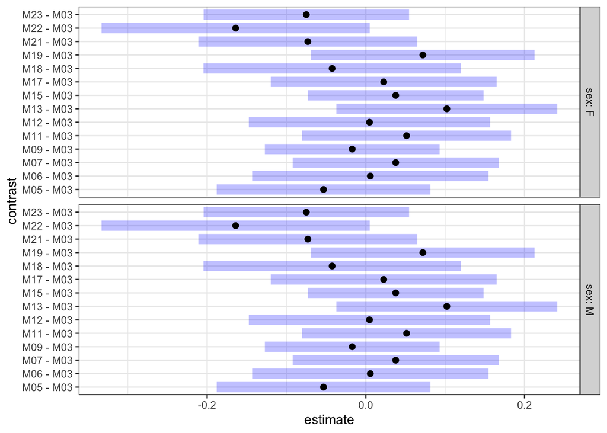

```r
plot(baseline_contrasts)
```

### 3.1 Observed index model

```r
model2_interaction <- lmer(Observed ~ sex * month + (1 | mousegroup.x) + (1 | mouse), data = df_wide)
drop1(model2_interaction,test="Chisq")
```

```
## Single term deletions using Satterthwaite's method:
##
## Model:
## Observed ~ sex * month + (1 | mousegroup.x) + (1 | mouse)
##           Sum Sq Mean Sq NumDF  DenDF F value Pr(>F)
## sex:month 8401.1  600.08    14 590.14  1.2106 0.2627
```

### 3.2 ANOVA for model1 (Observed with all cohorts)

```r
model2 <- lmer(Observed ~ sex + month + (1 | mousegroup.x) + (1 | mouse), data = df_wide)
```

```
## boundary (singular) fit: see help('isSingular')
```

```r
drop1(model2,test="Chisq")
```

```
## Single term deletions using Satterthwaite's method:
##
## Model:
## Observed ~ sex + month + (1 | mousegroup.x) + (1 | mouse)
##        Sum Sq Mean Sq NumDF  DenDF F value    Pr(>F)
## sex     858.8  858.84     1 605.48  1.7241    0.1897
## month 30533.2 2180.94    14 579.46  4.3783 1.855e-07 ***
## ---
## Signif. codes:  0 '***' 0.001 '**' 0.01 '*' 0.05 '.' 0.1 ' ' 1
```

```r
kable(anova(model2, type = 3), caption = "ANOVA for model1 with all cohort")
```

ANOVA for model1 with all cohort

|  | Sum Sq | Mean Sq | NumDF | DenDF | F value | Pr(>F) |
| --- | --- | --- | --- | --- | --- | --- |
| sex | 858.8369 | 858.8369 | 1 | 605.4835 | 1.724126 | 0.1896603 |
| month | 30533.2057 | 2180.9433 | 14 | 579.4636 | 4.378270 | 0.0000002 |

```r
kable(summary(model2)$coefficients, digits = 4)
```

|  | Estimate | Std. Error | df | t value | Pr(>\|t\|) |
| --- | --- | --- | --- | --- | --- |
| (Intercept) | 136.8296 | 4.4212 | 7.2648 | 30.9484 | 0.0000 |
| sexM | 2.3773 | 1.8105 | 605.4835 | 1.3131 | 0.1897 |
| monthM05 | 9.6620 | 4.5422 | 606.4008 | 2.1271 | 0.0338 |
| monthM06 | 6.1633 | 5.0084 | 601.6720 | 1.2306 | 0.2190 |
| monthM07 | 22.4603 | 4.3809 | 605.8598 | 5.1268 | 0.0000 |
| monthM09 | 8.4057 | 3.7312 | 604.1557 | 2.2528 | 0.0246 |
| monthM11 | 15.1570 | 4.4400 | 606.0792 | 3.4138 | 0.0007 |
| monthM12 | 7.1040 | 5.1171 | 602.3141 | 1.3883 | 0.1656 |
| monthM13 | 23.1323 | 4.6955 | 606.7096 | 4.9265 | 0.0000 |
| monthM15 | 11.2160 | 3.7553 | 604.2222 | 2.9867 | 0.0029 |
| monthM17 | 7.0414 | 4.7969 | 606.7176 | 1.4679 | 0.1426 |
| monthM18 | 9.5689 | 5.4555 | 604.0531 | 1.7540 | 0.0799 |
| monthM19 | 14.5630 | 4.7477 | 606.6353 | 3.0674 | 0.0023 |
| monthM21 | 2.5643 | 4.6515 | 606.6855 | 0.5513 | 0.5816 |
| monthM22 | -9.2755 | 5.6879 | 606.1274 | -1.6307 | 0.1035 |
| monthM23 | 6.5468 | 4.3707 | 606.3274 | 1.4979 | 0.1347 |

### 3.3 Estimated marginal means for model2 (Observed)

I did this to double check the above results. And we see similar findings.

```r
# Estimated marginal means by Sex within Month for Observed
## Q: Within each sex, how does each month differ from the reference month?

emm_month_within_sex_observed <- emmeans(model2, ~ month | sex)
baseline_contrasts_observed <- contrast(emm_month_within_sex_observed, method = "trt.vs.ctrl", ref = 1, by = "sex")
baseline_contrasts_observed
```

```
## sex = F:
##  contrast  estimate   SE  df t.ratio p.value
##  M05 - M03     9.66 4.57 553   2.116  0.2772
##  M06 - M03     6.16 5.05 543   1.221  0.8241
##  M07 - M03    22.46 4.41 546   5.098  <.0001
##  M09 - M03     8.41 3.73 559   2.251  0.2128
##  M11 - M03    15.16 4.46 550   3.395  0.0091
##  M12 - M03     7.10 5.16 545   1.378  0.7387
##  M13 - M03    23.13 4.72 558   4.902  <.0001
##  M15 - M03    11.22 3.76 551   2.985  0.0335
##  M17 - M03     7.04 4.82 565   1.460  0.6883
##  M18 - M03     9.57 5.49 557   1.742  0.5031
##  M19 - M03    14.56 4.77 561   3.051  0.0274
##  M21 - M03     2.56 4.68 562   0.549  0.9932
##  M22 - M03    -9.28 5.72 570  -1.621  0.5837
##  M23 - M03     6.55 4.39 546   1.490  0.6693
##
## sex = M:
##  contrast  estimate   SE  df t.ratio p.value
##  M05 - M03     9.66 4.57 553   2.116  0.2772
##  M06 - M03     6.16 5.05 543   1.221  0.8241
##  M07 - M03    22.46 4.41 546   5.098  <.0001
##  M09 - M03     8.41 3.73 559   2.251  0.2128
##  M11 - M03    15.16 4.46 550   3.395  0.0091
##  M12 - M03     7.10 5.16 545   1.378  0.7387
##  M13 - M03    23.13 4.72 558   4.902  <.0001
##  M15 - M03    11.22 3.76 551   2.985  0.0335
##  M17 - M03     7.04 4.82 565   1.460  0.6883
##  M18 - M03     9.57 5.49 557   1.742  0.5031
##  M19 - M03    14.56 4.77 561   3.051  0.0274
##  M21 - M03     2.56 4.68 562   0.549  0.9932
##  M22 - M03    -9.28 5.72 570  -1.621  0.5837
##  M23 - M03     6.55 4.39 546   1.490  0.6693
##
## Degrees-of-freedom method: kenward-roger
## P value adjustment: dunnettx method for 14 tests
```

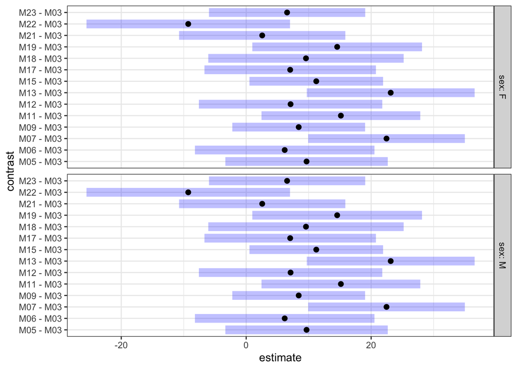

```r
plot(baseline_contrasts_observed)
```

## 4 Alpha Diversity of mice based on frailty

To determine potential relationship between frailty scores and survival, I filtered the dataset to the last time point of collection

```r
metadata<-read.delim("Young_aging_metadata_v4.txt")

# keeping only the last one per mouse
metadata_sub <- metadata %>%
  group_by(mouse) %>%
  arrange(month_n, .by_group = TRUE) %>%  # ensure chronological order
  slice_tail(n = 1) %>%
  ungroup()
```

This results in 186 mice

```r
#Remove samples with no frailty information
metadata_sub_f<-metadata_sub %>%
  filter(frailty_physical %in% c("PF","NF","F"))

write.table(metadata_sub_f,"metadata_frailty.txt",sep="\t", quote = FALSE,
            row.names = FALSE)

qiime_frail<-qza_to_phyloseq(features="Aging-table-dada2.qza",
                       tree="rooted-tree-merged.qza",
                       metadata="metadata_frailty.txt", taxonomy = "Aging-taxonomy-weighted_silva138-1.qza")

sample_reads <- sample_sums(qiime_frail)
sorted_reads <- sort(sample_reads)
print(sorted_reads)
```

```
## M2201N3M22 F2198N4M22 F2202N1M22 F2202N2M22 M2226N2M17 M2214N3M21 F2199N2M19
##       2235       3122       4328       4359       4762       4831       5191
## F2198N1M22 M2200N3M22 F2198N3M22 M2201N1M22 F2199N3M22 M2201N2M22 M2200N4M22
##       5401       6219       6418       6638       7040       7872       8958
## M2197N2M22 M2212N3M13 M2197N1M22 M2215N2M21 F2211N3M23 F2224N2M22 M2226N3M17
##       8997      10442      10554      10873      13653      16321      16495
## F2223N1M22 F2213N3M23 M2215N1M23 M2214N2M23 M2225N1M22 M2226N4M22 M2226N1M22
##      17012      17486      17781      17844      18262      18311      19661
## M2225N3M22 M2214N1M23 M2225N2M23 F2223N2M22 M2215N3M23 M2225N5M22 F2211N4M23
##      20406      21549      22186      22423      22656      25894      27221
## F2213N1M23 F2224N3M22 M2225N4M22 F2211N1M23 M2212N1M23 F2224N4M22
##      29614      31255      34634      35112      37080      43680
```

```r
save(qiime_frail, file="qiime_frail.RData")

qiime.rare.frail<- rarefy_even_depth(qiime_frail,sample.size = min(sample_sums(qiime_frail)))
```

```
## You set `rngseed` to FALSE. Make sure you've set & recorded
##  the random seed of your session for reproducibility.
## See `?set.seed`
```

```
## ...
```

```
## 3898OTUs were removed because they are no longer
## present in any sample after random subsampling
```

```
## ...
```

### 4.1 Alpha diversity

#### 4.1.1 I found no association with frailty scores and microbiota

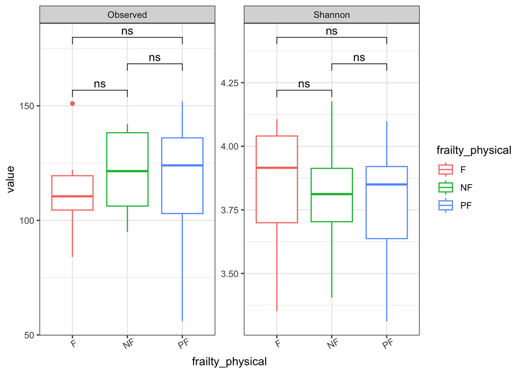

```r
metadata_df_frail<-as.data.frame(sample_data( qiime.rare.frail))
metadata_df_frail$SampleID<-rownames(metadata_df_frail)
metadata_df_frail<-as.matrix(metadata_df_frail)

alpha.div.df.frail <- estimate_richness(
  qiime.rare.frail,
  measures=c("Shannon", "Observed")) %>%
  rownames_to_column("SampleID") %>%
  merge(metadata_df_frail, by="SampleID")

alpha.div.df.frail.long <- alpha.div.df.frail %>%
  pivot_longer(c(Shannon, Observed), names_to="metric")

alpha.div.plot.df.frail <- alpha.div.df.frail.long %>%
  arrange(metric, frailty_physical)

a_my_comparisons_frail <-list(c("F","NF"),c("NF","PF"),c("PF","F"))
symnum.args <- list(cutpoints = c(0, 0.0001, 0.001, 0.01, 0.05, 1), symbols = c("****", "***", "**", "*", "ns"))

alpha.div.df.frail.long%>%
  ggplot(aes(x=frailty_physical, y=value, color=frailty_physical))+
geom_boxplot()+facet_wrap(~metric, scales="free")+
  theme_set(theme_bw())+
  theme(axis.text.x=element_text(angle=30))+
  stat_compare_means(comparisons = a_my_comparisons_frail, symnum.args = symnum.args, method = "wilcox.test")
```

```r
#No. sig difference found here
```

```r
df_wide_frail<- alpha.div.df.frail.long%>%
  pivot_wider(names_from = metric, values_from = value)
model_shannon_frail <- lmer(Shannon ~ frailty_physical + (1 | mousegroup.x), data = df_wide_frail)
```

```
## boundary (singular) fit: see help('isSingular')
```

```r
kable(summary(model_shannon_frail)$coefficients, digits = 4)
```

|  | Estimate | Std. Error | df | t value | Pr(>\|t\|) |
| --- | --- | --- | --- | --- | --- |
| (Intercept) | 3.8332 | 0.0909 | 38 | 42.1892 | 0.0000 |
| frailty_physicalNF | -0.0358 | 0.1113 | 38 | -0.3221 | 0.7491 |
| frailty_physicalPF | -0.0532 | 0.1020 | 38 | -0.5218 | 0.6048 |

```r
df_wide_frail$howlette_frailty<-as.numeric(df_wide_frail$howlette_frailty)
model_shannon_hf <- lmer(Shannon ~ howlette_frailty + (1 | mousegroup.x), data = df_wide_frail)
```

```
## boundary (singular) fit: see help('isSingular')
```

```r
kable(summary(model_shannon_hf)$coefficients, digits = 4)
```

|  | Estimate | Std. Error | df | t value | Pr(>\|t\|) |
| --- | --- | --- | --- | --- | --- |
| (Intercept) | 3.8294 | 0.1015 | 39 | 37.7226 | 0.0000 |
| howlette_frailty | -0.1532 | 0.3997 | 39 | -0.3833 | 0.7036 |

## 5 Subsetting per cohort (just a sanity check)

### 5.1 Cohort G1

```r
df_wide_G1<- df_wide %>%
  filter(mousegroup.x== "G1")
View(df_wide_G1)

model1_G1 <- lmer(Shannon ~ sex + month + (1 | mouse), data = df_wide_G1)
summary(model1_G1)
```

```
## Linear mixed model fit by REML. t-tests use Satterthwaite's method [
## lmerModLmerTest]
## Formula: Shannon ~ sex + month + (1 | mouse)
##    Data: df_wide_G1
##
## REML criterion at convergence: 1.8
##
## Scaled residuals:
##     Min      1Q  Median      3Q     Max
## -2.8890 -0.5855  0.1824  0.6548  2.4951
##
## Random effects:
##  Groups   Name        Variance Std.Dev.
##  mouse    (Intercept) 0.00000  0.0000
##  Residual             0.04724  0.2174
## Number of obs: 142, groups:  mouse, 19
##
## Fixed effects:
##               Estimate Std. Error         df t value Pr(>|t|)
## (Intercept)   3.942742   0.058154 131.000000  67.798   <2e-16 ***
## sexM          0.043298   0.036829 131.000000   1.176    0.242
## monthM05      0.009926   0.085226 131.000000   0.116    0.907
## monthM07     -0.039975   0.076847 131.000000  -0.520    0.604
## monthM09     -0.031581   0.076882 131.000000  -0.411    0.682
## monthM11     -0.030774   0.075784 131.000000  -0.406    0.685
## monthM13      0.138202   0.081164 131.000000   1.703    0.091 .
## monthM15      0.061231   0.078197 131.000000   0.783    0.435
## monthM17      0.098029   0.078346 131.000000   1.251    0.213
## monthM19      0.108576   0.079545 131.000000   1.365    0.175
## monthM22     -0.013052   0.090646 131.000000  -0.144    0.886
## ---
## Signif. codes:  0 '***' 0.001 '**' 0.01 '*' 0.05 '.' 0.1 ' ' 1
##
## Correlation of Fixed Effects:
##          (Intr) sexM   mntM05 mntM07 mntM09 mntM11 mntM13 mntM15 mntM17 mntM19
## sexM     -0.356
## monthM05 -0.612  0.047
## monthM07 -0.661  0.000  0.451
## monthM09 -0.671  0.030  0.452  0.500
## monthM11 -0.686  0.045  0.459  0.507  0.508
## monthM13 -0.629  0.011  0.427  0.473  0.474  0.481
## monthM15 -0.665  0.045  0.445  0.491  0.492  0.500  0.466
## monthM17 -0.675  0.076  0.446  0.490  0.492  0.501  0.465  0.485
## monthM19 -0.637 -0.004  0.435  0.483  0.483  0.490  0.457  0.475  0.473
## monthM22 -0.545 -0.042  0.380  0.424  0.422  0.428  0.401  0.415  0.413  0.410
## optimizer (nloptwrap) convergence code: 0 (OK)
## boundary (singular) fit: see help('isSingular')
```

```r
drop1(model1_G1,test="Chisq")
```

```
## Single term deletions using Satterthwaite's method:
##
## Model:
## Shannon ~ sex + month + (1 | mouse)
##        Sum Sq  Mean Sq NumDF DenDF F value Pr(>F)
## sex   0.06530 0.065297     1   131  1.3821 0.2419
## month 0.55932 0.062147     9   131  1.3154 0.2348
```

```r
# From the summary result: There was no difference between sexes at M03, or difference with females, or relationship to M-F relative to baseline
```

```r
kable(anova(model1_G1, type = 3), caption ="ANOVA for Cohort G1: Shannon")
```

ANOVA for Cohort G1: Shannon

|  | Sum Sq | Mean Sq | NumDF | DenDF | F value | Pr(>F) |
| --- | --- | --- | --- | --- | --- | --- |
| sex | 0.065297 | 0.0652970 | 1 | 131 | 1.382128 | 0.2418713 |
| month | 0.559321 | 0.0621468 | 9 | 131 | 1.315447 | 0.2348092 |

```r
model2_G1 <- lmer(Observed ~ sex * month + (1 | mouse), data = df_wide_G1)
```

```
## boundary (singular) fit: see help('isSingular')
```

### 5.2 cohort G1: Observed

From the below table:

|  | Estimate | Std. Error | df | t value | Pr(>\|t\|) |
| --- | --- | --- | --- | --- | --- |
| (Intercept) | 123.1429 | 8.4062 | 122 | 14.6491 | 0.0000 |
| sexM | 2.3016 | 11.2082 | 122 | 0.2053 | 0.8376 |
| monthM05 | 5.5238 | 12.3736 | 122 | 0.4464 | 0.6561 |
| monthM07 | 45.4286 | 11.8881 | 122 | 3.8213 | 0.0002 |
| monthM09 | 45.8571 | 11.5106 | 122 | 3.9839 | 0.0001 |
| monthM11 | 16.9683 | 11.2082 | 122 | 1.5139 | 0.1326 |
| monthM13 | 46.1905 | 12.3736 | 122 | 3.7330 | 0.0003 |
| monthM15 | 32.1071 | 11.5106 | 122 | 2.7893 | 0.0061 |
| monthM17 | 28.6349 | 11.2082 | 122 | 2.5548 | 0.0119 |
| monthM19 | 7.0238 | 12.3736 | 122 | 0.5676 | 0.5713 |
| monthM22 | -14.4762 | 15.3475 | 122 | -0.9432 | 0.3474 |
| sexM:monthM05 | -8.7683 | 17.5213 | 122 | -0.5004 | 0.6177 |
| sexM:monthM07 | -6.4286 | 15.8509 | 122 | -0.4056 | 0.6858 |
| sexM:monthM09 | -15.0516 | 15.7888 | 122 | -0.9533 | 0.3423 |
| sexM:monthM11 | 8.2123 | 15.5697 | 122 | 0.5275 | 0.5988 |
| sexM:monthM13 | -2.4921 | 16.6952 | 122 | -0.1493 | 0.8816 |
| sexM:monthM15 | -12.5516 | 16.0661 | 122 | -0.7812 | 0.4362 |
| sexM:monthM17 | -15.0794 | 16.2181 | 122 | -0.9298 | 0.3543 |
| sexM:monthM19 | 28.5317 | 16.4285 | 122 | 1.7367 | 0.0850 |
| sexM:monthM22 | 17.1984 | 19.3119 | 122 | 0.8906 | 0.3749 |

### 5.3 ANOVA of ModelG1: Observed

|  | Sum Sq | Mean Sq | NumDF | DenDF | F value | Pr(>F) |
| --- | --- | --- | --- | --- | --- | --- |
| sex | 91.47856 | 91.47856 | 1 | 122 | 0.1849369 | 0.6679231 |
| month | 36277.26342 | 4030.80705 | 9 | 122 | 8.1488478 | 2.09e-09 *** |
| sex:month | 6297.16741 | 699.68527 | 9 | 122 | 1.4145130 | 0.1890481 |

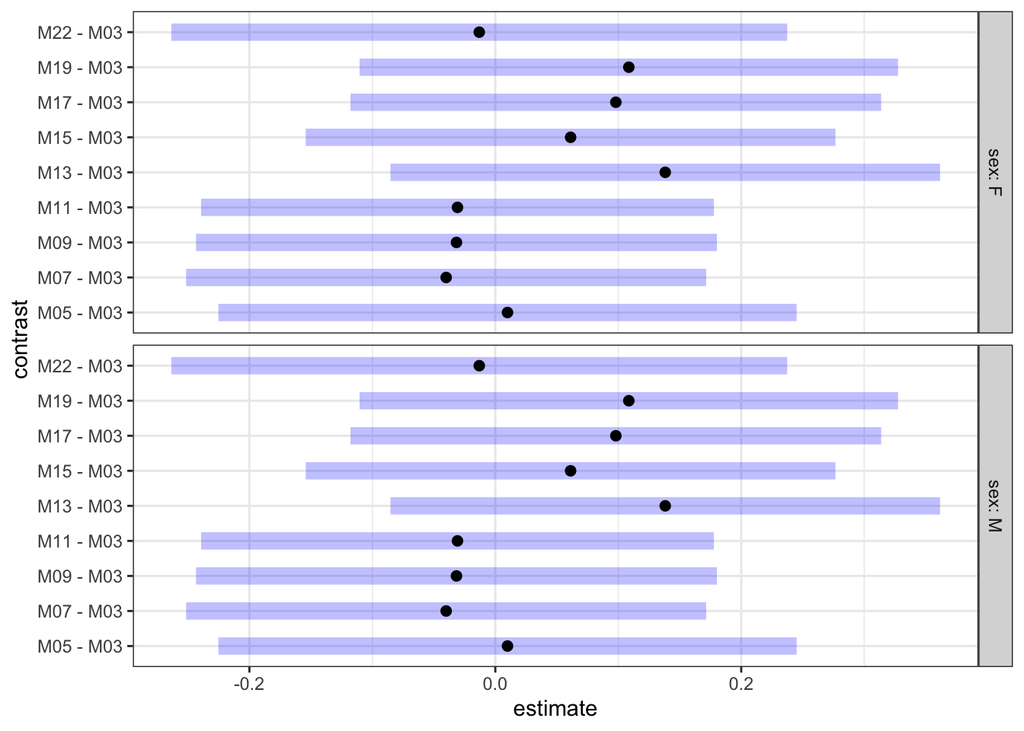

```r
# Estimated marginal means by Sex within Month for Shannon
emm_sex_within_month_G1 <- emmeans(model1_G1, ~ sex | month)
pairs_sex_within_month_G1 <- contrast(emm_sex_within_month_G1, method = "pairwise", adjust = "holm")

emm_month_within_sex_G1 <- emmeans(model1_G1, ~ month | sex)
baseline_contrasts_G1 <- contrast(emm_month_within_sex_G1, method = "trt.vs.ctrl", ref = 1, by = "sex")

plot(baseline_contrasts_G1)
```

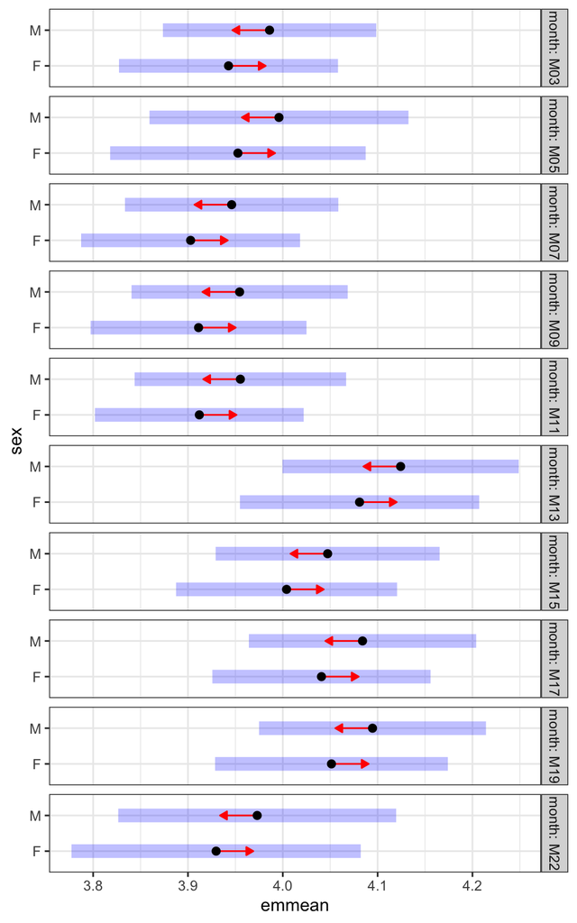

```r
plot(emm_sex_within_month_G1, comparisons = TRUE)
```

### 5.4 Cohort C

```r
df_wide_C<- df_wide %>%
  filter(mousegroup.x== "C")
model1_C <- lmer(Shannon ~ sex * month + (1 | mouse), data = df_wide_C)
```

### 5.5 Summary Cohort C: Shannon

From the below table:

1. There is sig. difference between male and females at M03 (p=0.0005)
2. Females shannon diversity relatively stable with age
3. Compared to the difference between males and females in M03, there was sig difference (decreasing) between Males and Females in months M12 (p= 0.0347), M15 (p=0.0320), and M23 (p=0.0006)

|  | Estimate | Std. Error | df | t value | Pr(>\|t\|) |
| --- | --- | --- | --- | --- | --- |
| (Intercept) | 3.8023 | 0.0608 | 219.0609 | 62.5293 | 0.0000 |
| sexM | 0.2902 | 0.0821 | 218.7018 | 3.5329 | 0.0005 |
| monthM06 | 0.0473 | 0.0810 | 193.8009 | 0.5838 | 0.5600 |
| monthM09 | 0.0858 | 0.0792 | 201.6122 | 1.0829 | 0.2802 |
| monthM12 | 0.1241 | 0.0838 | 196.9755 | 1.4807 | 0.1403 |
| monthM15 | 0.0797 | 0.0810 | 193.8009 | 0.9837 | 0.3265 |
| monthM18 | 0.0662 | 0.0891 | 193.1763 | 0.7423 | 0.4588 |
| monthM21 | 0.0266 | 0.0822 | 192.6006 | 0.3238 | 0.7464 |
| monthM23 | 0.1353 | 0.0798 | 192.4630 | 1.6951 | 0.0917 |
| sexM:monthM06 | -0.1082 | 0.1128 | 195.5182 | -0.9591 | 0.3387 |
| sexM:monthM09 | -0.1615 | 0.1170 | 202.4634 | -1.3803 | 0.1690 |
| sexM:monthM12 | -0.2441 | 0.1148 | 196.0534 | -2.1268 | 0.0347 |
| sexM:monthM15 | -0.2437 | 0.1128 | 195.9673 | -2.1600 | 0.0320 |
| sexM:monthM18 | -0.2234 | 0.1210 | 196.4263 | -1.8459 | 0.0664 |
| sexM:monthM21 | -0.2252 | 0.1161 | 198.1406 | -1.9398 | 0.0538 |
| sexM:monthM23 | -0.3868 | 0.1101 | 193.5140 | -3.5121 | 0.0006 |

```r
kable(anova(model1_C, type = 3), caption = "ANOVA for model1 (Shannon)_C")
```

ANOVA for model1 (Shannon)_C

|  | Sum Sq | Mean Sq | NumDF | DenDF | F value | Pr(>F) |
| --- | --- | --- | --- | --- | --- | --- |
| sex | 0.3515279 | 0.3515279 | 1 | 36.76344 | 7.2853516 | 0.0104402 |
| month | 0.2405358 | 0.0343623 | 7 | 197.72563 | 0.7121516 | 0.6617764 |
| sex:month | 0.6295187 | 0.0899312 | 7 | 197.72563 | 1.8638086 | 0.0773267 |

```r
model2_C <- lmer(Observed ~ sex * month + (1 | mouse), data = df_wide_C)
```

```
## boundary (singular) fit: see help('isSingular')
```

```r
kable(summary(model2_C)$coefficients, digits = 4, caption = "Fixed effects for Observed model (Cohort C)")
```

Fixed effects for Observed model (Cohort C)

|  | Estimate | Std. Error | df | t value | Pr(>\|t\|) |
| --- | --- | --- | --- | --- | --- |
| (Intercept) | 141.1429 | 4.4816 | 221 | 31.4940 | 0.0000 |
| sexM | 7.2101 | 6.0518 | 221 | 1.1914 | 0.2348 |
| monthM06 | 2.0446 | 6.1367 | 221 | 0.3332 | 0.7393 |
| monthM09 | 0.2460 | 5.9754 | 221 | 0.0412 | 0.9672 |
| monthM12 | 10.5714 | 6.3379 | 221 | 1.6680 | 0.0967 |
| monthM15 | 8.7321 | 6.1367 | 221 | 1.4229 | 0.1562 |
| monthM18 | 7.7662 | 6.7562 | 221 | 1.1495 | 0.2516 |
| monthM21 | 10.7238 | 6.2314 | 221 | 1.7209 | 0.0867 |
| monthM23 | 9.1513 | 6.0518 | 221 | 1.5121 | 0.1319 |
| sexM:monthM06 | 1.2691 | 8.5407 | 221 | 0.1486 | 0.8820 |
| sexM:monthM09 | 5.0374 | 8.8209 | 221 | 0.5711 | 0.5685 |
| sexM:monthM12 | -13.7910 | 8.6865 | 221 | -1.5876 | 0.1138 |
| sexM:monthM15 | -10.6184 | 8.5407 | 221 | -1.2433 | 0.2151 |
| sexM:monthM18 | -3.6576 | 9.1551 | 221 | -0.3995 | 0.6899 |
| sexM:monthM21 | -15.1537 | 8.7750 | 221 | -1.7269 | 0.0856 |
| sexM:monthM23 | -11.7395 | 8.3490 | 221 | -1.4061 | 0.1611 |

#### 5.5.1 In cohort C, no differences in Observed diversity metric.

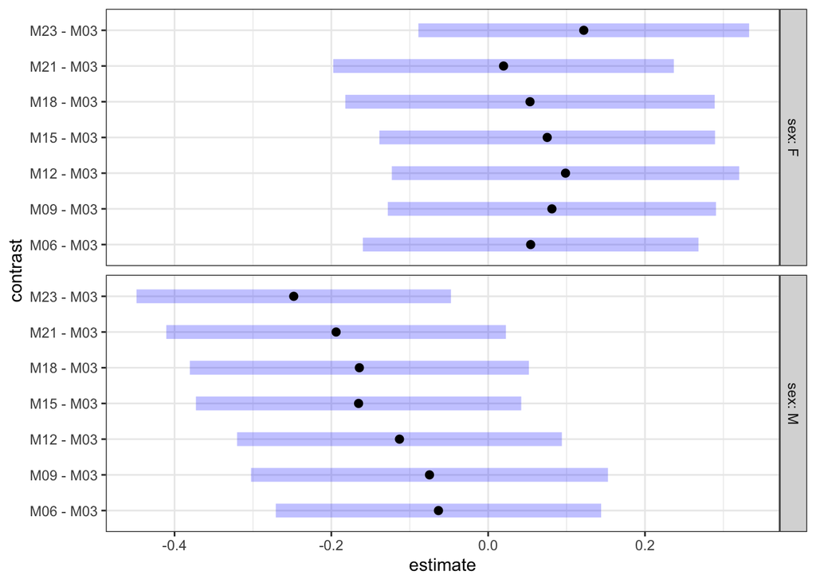

```r
# Estimated marginal means by Sex within Month for Shannon
emm_sex_within_month_C <- emmeans(model1_C, ~ sex | month)
pairs_sex_within_month_C <- contrast(emm_sex_within_month_C, method = "pairwise", adjust = "holm")

emm_month_within_sex_C <- emmeans(model1_C, ~ month | sex)
baseline_contrasts_C <- contrast(emm_month_within_sex_C, method = "trt.vs.ctrl", ref = 1, by = "sex")

plot(baseline_contrasts_C)
```

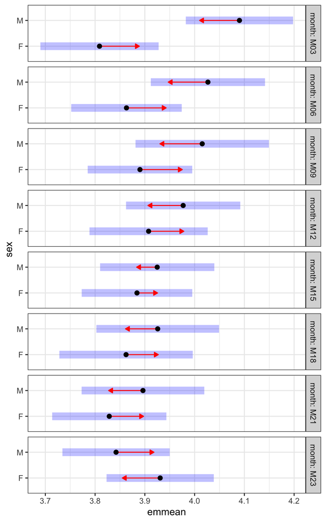

```r
plot(emm_sex_within_month_C, comparisons = TRUE)
```

### 5.6 For Cohort G2

SHANNON

|  | Estimate | Std. Error | df | t value | Pr(>\|t\|) |
| --- | --- | --- | --- | --- | --- |
| (Intercept) | 3.7939 | 0.1246 | 101.2543 | 30.4592 | 0.0000 |
| sexM | 0.1223 | 0.1505 | 99.3598 | 0.8126 | 0.4184 |
| monthM05 | -0.2431 | 0.1490 | 92.9471 | -1.6313 | 0.1062 |
| monthM07 | 0.3279 | 0.1489 | 92.7019 | 2.2017 | 0.0302 |
| monthM09 | 0.0667 | 0.1499 | 94.2028 | 0.4450 | 0.6574 |
| monthM11 | 0.1733 | 0.1713 | 97.3980 | 1.0116 | 0.3142 |
| monthM13 | 0.0261 | 0.1600 | 94.1260 | 0.1631 | 0.8708 |
| monthM15 | 0.1091 | 0.1847 | 96.9481 | 0.5908 | 0.5560 |
| monthM17 | -0.0433 | 0.1544 | 94.8884 | -0.2803 | 0.7799 |
| monthM19 | 0.3025 | 0.1544 | 94.8884 | 1.9587 | 0.0531 |
| monthM21 | -0.0113 | 0.1825 | 94.0437 | -0.0618 | 0.9509 |
| monthM23 | -0.0786 | 0.1600 | 94.2136 | -0.4913 | 0.6244 |
| sexM:monthM05 | 0.2209 | 0.1907 | 92.3040 | 1.1579 | 0.2499 |
| sexM:monthM07 | -0.2129 | 0.1995 | 92.9569 | -1.0674 | 0.2886 |
| sexM:monthM09 | -0.1397 | 0.1915 | 93.3516 | -0.7293 | 0.4677 |
| sexM:monthM11 | -0.1075 | 0.2087 | 95.8024 | -0.5149 | 0.6078 |
| sexM:monthM13 | 0.0446 | 0.1995 | 93.2802 | 0.2236 | 0.8236 |
| sexM:monthM15 | -0.1136 | 0.2231 | 95.7534 | -0.5091 | 0.6119 |
| sexM:monthM17 | 0.0029 | 0.2036 | 94.1650 | 0.0142 | 0.9887 |
| sexM:monthM19 | -0.2752 | 0.2108 | 94.4461 | -1.3056 | 0.1949 |
| sexM:monthM21 | -0.0380 | 0.2256 | 93.7753 | -0.1683 | 0.8667 |
| sexM:monthM23 | -0.0581 | 0.2079 | 93.9131 | -0.2794 | 0.7805 |

OBSERVED For G2

1. No diff at baseline
2. M07 and M19 females are diff from M03
3. Marginal diff between M and F in M19

Fixed effects for Observed model (Cohort G2)

|  | Estimate | Std. Error | df | t value | Pr(>\|t\|) |
| --- | --- | --- | --- | --- | --- |
| (Intercept) | 116.9246 | 11.8680 | 100.9588 | 9.8521 | 0.0000 |
| sexM | 13.2977 | 14.3580 | 98.5733 | 0.9261 | 0.3566 |
| monthM05 | 11.7280 | 14.1262 | 92.5827 | 0.8302 | 0.4085 |
| monthM07 | 45.4176 | 14.1182 | 92.3351 | 3.2170 | 0.0018 |
| monthM09 | 24.7788 | 14.2162 | 93.7734 | 1.7430 | 0.0846 |
| monthM11 | 13.0188 | 16.2621 | 96.9500 | 0.8006 | 0.4253 |
| monthM13 | 3.5086 | 15.1743 | 93.7729 | 0.2312 | 0.8176 |
| monthM15 | 16.5746 | 17.5303 | 96.4958 | 0.9455 | 0.3468 |
| monthM17 | 17.7518 | 14.6462 | 94.5244 | 1.2120 | 0.2285 |
| monthM19 | 56.7518 | 14.6462 | 94.5244 | 3.8748 | 0.0002 |
| monthM21 | -10.5578 | 17.3059 | 93.6354 | -0.6101 | 0.5433 |
| monthM23 | 17.0319 | 15.1767 | 93.8676 | 1.1222 | 0.2646 |
| sexM:monthM05 | 15.8732 | 18.0796 | 91.9626 | 0.8780 | 0.3823 |
| sexM:monthM07 | -24.2694 | 18.9094 | 92.6070 | -1.2835 | 0.2025 |
| sexM:monthM09 | -13.9993 | 18.1584 | 92.9841 | -0.7710 | 0.4427 |
| sexM:monthM11 | 2.7607 | 19.8010 | 95.3951 | 0.1394 | 0.8894 |
| sexM:monthM13 | 15.7810 | 18.9142 | 92.9558 | 0.8343 | 0.4062 |
| sexM:monthM15 | -9.2275 | 21.1623 | 95.3389 | -0.4360 | 0.6638 |
| sexM:monthM17 | -8.5881 | 19.3048 | 93.8117 | -0.4449 | 0.6574 |
| sexM:monthM19 | -37.3228 | 19.9866 | 94.0765 | -1.8674 | 0.0650 |
| sexM:monthM21 | 5.2741 | 21.3946 | 93.3928 | 0.2465 | 0.8058 |
| sexM:monthM23 | -8.5674 | 19.7165 | 93.5724 | -0.4345 | 0.6649 |

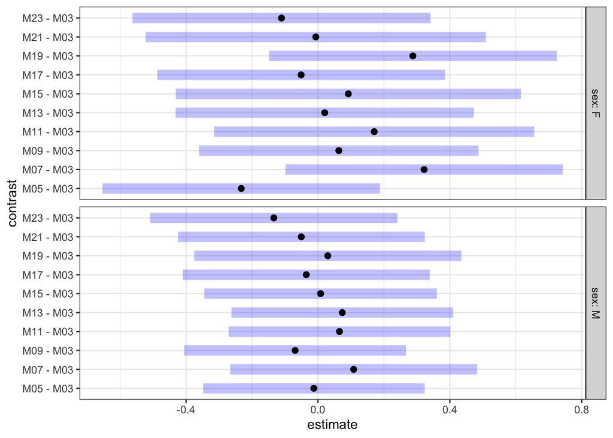

```r
# Estimated marginal means by Sex within Month for Shannon
df_wide_G2<- df_wide %>%
  filter(mousegroup.x== "G2")

model1_G2 <- lmer(Shannon ~ sex * month + (1 | mouse), data = df_wide_G2)
emm_sex_within_month_G2 <- emmeans(model1_G2, ~ sex | month)
pairs_sex_within_month_G2 <- contrast(emm_sex_within_month_G2, method = "pairwise", adjust = "holm")

emm_month_within_sex_G2 <- emmeans(model1_G2, ~ month | sex)
baseline_contrasts_G2 <- contrast(emm_month_within_sex_G2, method = "trt.vs.ctrl", ref = 1, by = "sex")

plot(baseline_contrasts_G2)
```

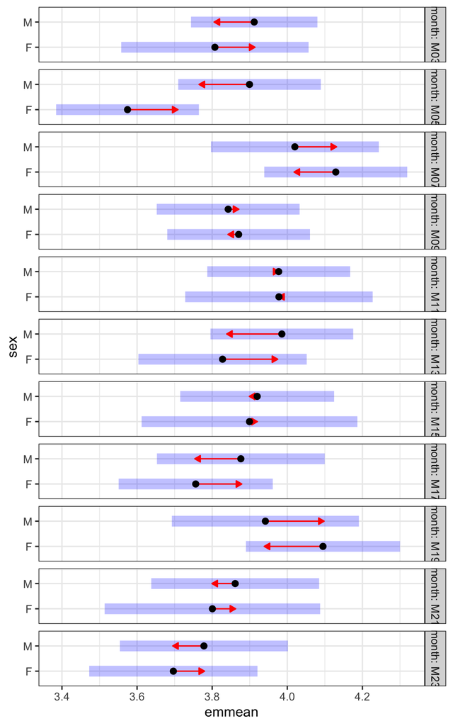

```r
plot(emm_sex_within_month_G2, comparisons = TRUE)
```

### 5.7 Cohort G3

OBSERVED

M11 females diff from M03 females

|  | Estimate | Std. Error | df | t value | Pr(>\|t\|) |
| --- | --- | --- | --- | --- | --- |
| (Intercept) | 151.6000 | 9.3928 | 100 | 16.1401 | 0.0000 |
| sexM | 4.4000 | 11.5037 | 100 | 0.3825 | 0.7029 |
| monthM05 | 4.6000 | 13.2834 | 100 | 0.3463 | 0.7298 |
| monthM07 | -2.2667 | 12.7179 | 100 | -0.1782 | 0.8589 |
| monthM09 | 8.4000 | 15.3383 | 100 | 0.5476 | 0.5852 |
| monthM11 | 33.9000 | 14.0892 | 100 | 2.4061 | 0.0180 |
| monthM13 | 11.1500 | 14.0892 | 100 | 0.7914 | 0.4306 |
| monthM15 | 8.0667 | 15.3383 | 100 | 0.5259 | 0.6001 |
| monthM17 | -29.6000 | 23.0075 | 100 | -1.2865 | 0.2012 |
| monthM19 | -5.8000 | 13.2834 | 100 | -0.4366 | 0.6633 |
| monthM22 | -20.7667 | 12.7179 | 100 | -1.6329 | 0.1056 |
| monthM23 | -14.0000 | 22.0280 | 100 | -0.6356 | 0.5265 |
| sexM:monthM05 | 12.5111 | 16.4187 | 100 | 0.7620 | 0.4479 |
| sexM:monthM07 | 2.9667 | 15.8104 | 100 | 0.1876 | 0.8515 |
| sexM:monthM09 | -44.2571 | 18.5039 | 100 | -2.3918 | 0.0186 |
| sexM:monthM11 | -25.0000 | 16.9331 | 100 | -1.4764 | 0.1430 |
| sexM:monthM13 | 13.3500 | 17.7802 | 100 | 0.7508 | 0.4545 |
| sexM:monthM15 | 5.3778 | 18.1215 | 100 | 0.2968 | 0.7673 |
| sexM:monthM17 | 24.1000 | 25.4357 | 100 | 0.9475 | 0.3457 |
| sexM:monthM19 | -13.6000 | 17.5723 | 100 | -0.7739 | 0.4408 |
| sexM:monthM22 | 13.2667 | 16.7146 | 100 | 0.7937 | 0.4292 |

SHANNON

|  | Estimate | Std. Error | df | t value | Pr() |
| --- | --- | --- | --- | --- | --- |
| (Intercept) | 3.9141 | 0.1000 | 100 | 39.1539 | 0.0000 |
| sexM | 0.0736 | 0.1224 | 100 | 0.6010 | 0.5492 |
| monthM05 | 0.0475 | 0.1414 | 100 | 0.3358 | 0.7377 |
| monthM07 | 0.0356 | 0.1354 | 100 | 0.2631 | 0.7930 |
| monthM09 | 0.1372 | 0.1632 | 100 | 0.8405 | 0.4026 |
| monthM11 | 0.1876 | 0.1499 | 100 | 1.2514 | 0.2137 |
| monthM13 | 0.1749 | 0.1499 | 100 | 1.1666 | 0.2462 |
| monthM15 | 0.3460 | 0.1632 | 100 | 2.1197 | 0.0365* |
| monthM17 | 0.2787 | 0.2449 | 100 | 1.1383 | 0.2577 |
| monthM19 | -0.0303 | 0.1414 | 100 | -0.2143 | 0.8307 |
| monthM22 | -0.3130 | 0.1354 | 100 | -2.3122 | 0.0228* |
| sexM:monthM05 | -0.0310 | 0.1747 | 100 | -0.1777 | 0.8594 |
| sexM:monthM07 | -0.0396 | 0.1683 | 100 | -0.2354 | 0.8144 |
| sexM:monthM09 | -0.2277 | 0.1969 | 100 | -1.1564 | 0.2503 |
| sexM:monthM11 | -0.0360 | 0.1802 | 100 | -0.2000 | 0.8419 |
| sexM:monthM13 | 0.0120 | 0.1892 | 100 | 0.0635 | 0.9495 |
| sexM:monthM15 | -0.1370 | 0.1929 | 100 | -0.7106 | 0.4790 |
| sexM:monthM17 | -0.3000 | 0.2707 | 100 | -1.1080 | 0.2705 |
| sexM:monthM19 | -0.0251 | 0.1870 | 100 | -0.1342 | 0.8935 |
| sexM:monthM22 | 0.1546 | 0.1779 | 100 | 0.8691 | 0.3869 |

```r
# Estimated marginal means by Sex within Month for Shannon
df_wide_G3<- df_wide %>%
  filter(mousegroup.x== "G3")

model1_G3 <- lmer(Shannon ~ sex * month + (1 | mouse), data = df_wide_G3)
```

```
## boundary (singular) fit: see help('isSingular')
```

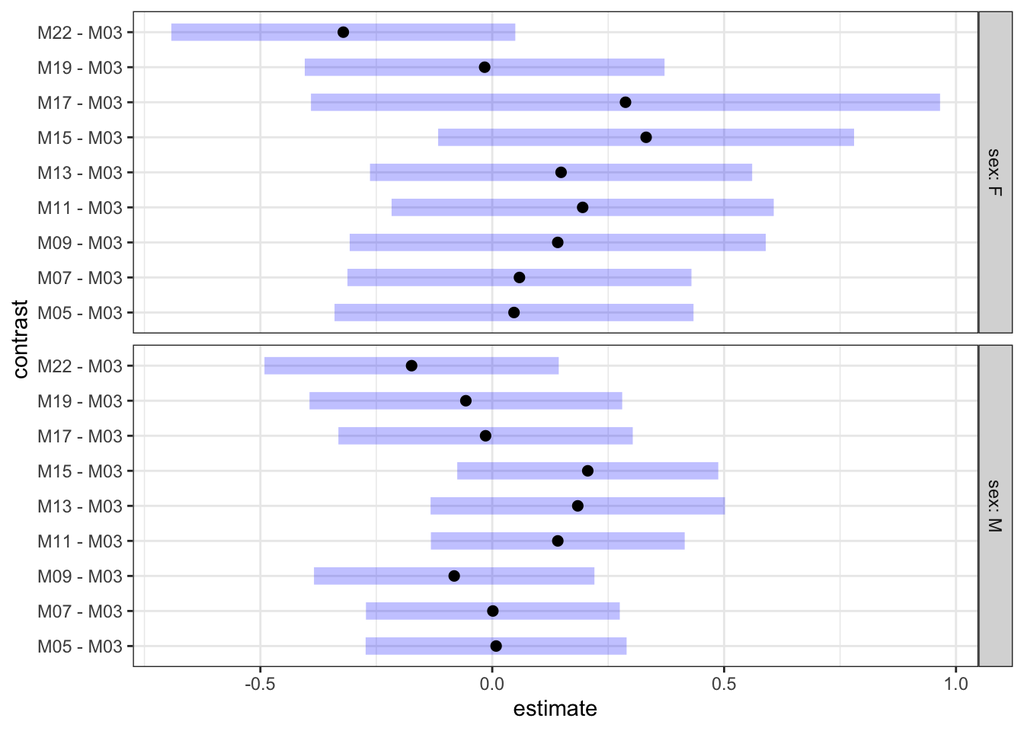

```r
emm_sex_within_month_G3 <- emmeans(model1_G3, ~ sex | month)
pairs_sex_within_month_G3 <- contrast(emm_sex_within_month_G3, method = "pairwise", adjust = "holm")

emm_month_within_sex_G3 <- emmeans(model1_G3, ~ month | sex)
baseline_contrasts_G3 <- contrast(emm_month_within_sex_G3, method = "trt.vs.ctrl", ref = 1, by = "sex")

plot(baseline_contrasts_G3)
```

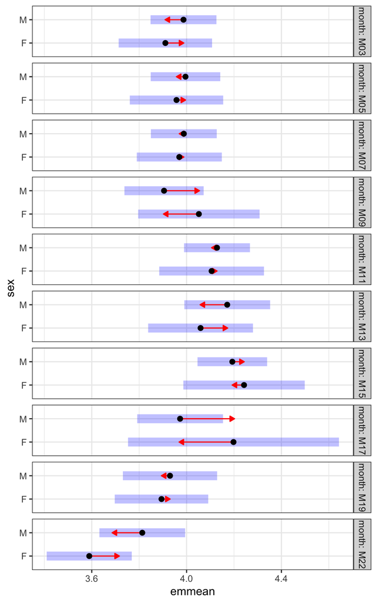

```r
plot(emm_sex_within_month_G3, comparisons = TRUE)
```